# QTM 151 Final Project

By Steven Liu, Sammi Mi, Stoney Zhou, Zhan Huanzhe (Joshua)

```python
# import pandas as pd
# import matplotlib.pyplot as plt
# import math
# import numpy as np
# # from scipy.stats import linregress
from scipy.optimize import curve_fit
import pandas as pd
import matplotlib.pyplot as plt
import math
import numpy as np
import seaborn as sns
import warnings

warnings.simplefilter(action='ignore', category=UserWarning)

excel_path = "data/HRMI_Website_Dataset_2024.6.20.xlsx"
```

```python
df = pd.read_excel(excel_path, sheet_name="People_at_Risk")

rights = [
    "arrest", "assem", "disap", "dpex", "exkill", "express", "polpart",
    "relig", "tort", "food", "educ", "health", "house", "work",
    "job", "jobcond", "union"
]

full_name = {
    "arrest": "Arbitrary Arrest",
    "assem": "Freedom of Assembly",
    "disap": "Disappearance",
    "dpex": "Deportation or Expulsion",
    "exkill": "Extrajudicial Killing",
    "express": "Freedom of Expression",
    "polpart": "Political Participation",
    "relig": "Freedom of Religion",
    "tort": "Torture or Ill-treatment",
    "food": "Access to Food",
    "educ": "Access to Education",
    "health": "Access to Healthcare",
    "house": "Access to Housing",
    "work": "Employment Opportunity",
    "job": "Employment Status",
    "jobcond": "Working Conditions",
    "union": "Labor Union Access"
}

climate_code = "37"
allpeople_code = "1"
```

# Topic 1: Are Climate Vulnerable Poeple More Likely To Face Difference Risks in their Rights than the General Population?

## Introduction

For the first topic, we aim to explore the relationship between climate-vulnerable groups and the general population across various risk factors. This is motivated by the understanding that climate change is a multifaceted, global issue, encompassing a wide range of challenges. Climate-vulnerable populations are often exposed to disproportionate environmental, social, and economic impacts, and we hypothesize that these individuals might also be more susceptible to other forms of disadvantage. Given the scale and complexity of the climate crisis, it is highly likely that people who are already vulnerable in terms of climate exposure are similarly underrepresented or disadvantaged across other domains of life, such as health, income, or political power. Thus, we aim to specifically investigate whether climate-affected groups are more prone to risks in areas beyond climate-related vulnerabilities, compared to the general population.

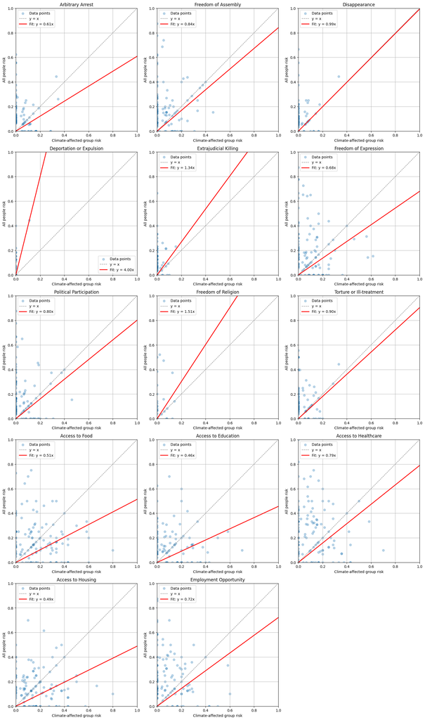

```python
num_plots = len(rights)
cols = 3
rows = math.ceil(num_plots / cols)

fig, axes = plt.subplots(rows, cols, figsize=(cols * 5.5, rows * 5.5))
axes = axes.flatten()

for i, right in enumerate(rights):
    col_x = f"{right}_atrisk_prop{climate_code}"
    col_y = f"{right}_atrisk_prop{allpeople_code}"

    if col_x in df.columns and col_y in df.columns:
        x = df[col_x]
        y = df[col_y]

        valid = x.notna() & y.notna()
        x = x[valid].values
        y = y[valid].values

        ax = axes[i]
        ax.scatter(x, y, alpha=0.3, label='Data points')

        ax.plot([0, 1], [0, 1], color='gray', linestyle='--', linewidth=1, label='y = x')

        # if len(x) > 1:
        #     try:
        #         x_reshaped = x.reshape(-1, 1)
        #         model = sm.OLS(y, x_reshaped)
        #         result = model.fit()
        #         slope = result.params[0]
        #         x_line = np.array([0, 1])
        #         y_line = slope * x_line
        #         ax.plot(x_line, y_line, color='red', linewidth=2,
        #                 label=f'Fit: y = {slope:.2f}x')
        #     except:
        #         pass

        if len(x) > 1:
            try:
                params, covariance = curve_fit(lambda x, b1: b1 * x, x, y)
                b1 = params[0]

                x_line = np.array([0, 1])
                y_line = b1 * x_line
                ax.plot(x_line, y_line, color='red', linewidth=2,
                        label=f'Fit: y = {b1:.2f}x')

            except Exception as e:
                print(f"Error in fitting {right}: {e}")

        ax.set_title(full_name.get(right, right))
        ax.set_xlabel("Climate-affected group risk")
        ax.set_ylabel("All people risk")
        ax.set_xlim(0, 1)
        ax.set_ylim(0, 1)
        ax.grid(True)
        ax.legend()
    else:
        axes[i].set_visible(False)

for j in range(i + 1, len(axes)):
    axes[j].set_visible(False)

plt.tight_layout()
plt.show()
```